# Analyses: Timing of Recruitment in Fire Refugia (unburned)

Anna Talucci

July 19, 2019

# Overview

The purpose of this analysis is to determine when seedlings are establishing in unburned plots to see if there are any patterns in are specific increases in seedling establishment associated with mountain pine beetle outbreak.

Analysis is at the plot level. Saplings in each plot were surveyed for number of branch whorls as a proxy for age. The age of seedlings was used to calculate an establishment date. The establishment dates were used to split saplings into groups.

The groupings created plots with repeated measures. Plots were replicates. Because of the repeated measures associated with the groupings mixed models were used for analysis with the plot as the random effect.

# Packages

The following Packages are required for the below analyses:

```r
library(dplyr)
library(tidyr)
library(ggplot2)
library(lme4)
library(MASS)
library(lsmeans)
library(DHARMa)
library(cowplot)
```

# Data

```r
whorl = read.csv("../data/chapter2_analysis2_unburnedsaplings_5december2017.csv", header=TRUE, sep = ",", strip.white = TRUE)

head(whorl)
```

```
##   plot.no      date   plot.id sapling.id all.whorls leader whorl.leader
## 1      64 6/30/2016 CEC0630U1        se1         16      1           17
## 2      64 6/30/2016 CEC0630U1        se2         34      1           35
## 3      64 6/30/2016 CEC0630U1        ne1         29      1           30
## 4      64 6/30/2016 CEC0630U1        ne2         28      1           29
## 5      64 6/30/2016 CEC0630U1        ne3         16      1           17
## 6      64 6/30/2016 CEC0630U1        ne4         12      1           13
##   false.whorls survey.year est.year est.f.year DBH disturbance
## 1           NA        2016     1999       1999 5.5 beetle.only
## 2           NA        2016     1981       1981 7.5 beetle.only
## 3           NA        2016     1986       1986 7.5 beetle.only
## 4           NA        2016     1987       1987 4.5 beetle.only
## 5           NA        2016     1999       1999 3.0 beetle.only
## 6           NA        2016     2003       2003 1.0 beetle.only
```

```r
summary(whorl)
```

```
##     plot.no             date          plot.id      sapling.id
##  Min.   :64.00   7/29/2016:111   BA0729U2 : 69   sw1    : 19
##  1st Qu.:70.00   8/1/2016 : 74   BA0801U1 : 61   nw1    : 18
##  Median :75.00   7/8/2016 : 73   TL0809U1 : 48   nw2    : 18
##  Mean   :74.53   8/12/2016: 59   BA0729U1 : 42   se1    : 18
##  3rd Qu.:79.00   8/9/2016 : 48   CEC0703U1: 40   ne1    : 17
##  Max.   :83.00   7/3/2016 : 40   CEC0780U2: 37   se2    : 17
##                  (Other)  :147   (Other)  :255   (Other):445
##    all.whorls        leader        whorl.leader    false.whorls
##  Min.   : 0.00   Min.   :0.0000   Min.   : 1.00   Min.   :0.0000
##  1st Qu.: 5.00   1st Qu.:1.0000   1st Qu.: 6.00   1st Qu.:0.0000
##  Median :10.00   Median :1.0000   Median :11.00   Median :0.0000
##  Mean   :11.89   Mean   :0.9964   Mean   :12.89   Mean   :0.3417
##  3rd Qu.:16.00   3rd Qu.:1.0000   3rd Qu.:17.00   3rd Qu.:0.0000
##  Max.   :48.00   Max.   :1.0000   Max.   :49.00   Max.   :6.0000
##                                                   NA's   :154
##   survey.year      est.year      est.f.year        DBH
##  Min.   :2016   Min.   :1967   Min.   :1967   Min.   : 0.500
##  1st Qu.:2016   1st Qu.:1999   1st Qu.:1998   1st Qu.: 0.500
##  Median :2016   Median :2005   Median :2005   Median : 1.000
##  Mean   :2016   Mean   :2003   Mean   :2003   Mean   : 1.699
##  3rd Qu.:2016   3rd Qu.:2010   3rd Qu.:2010   3rd Qu.: 2.000
##  Max.   :2016   Max.   :2015   Max.   :2015   Max.   :10.000
##
##       disturbance
##  beetle.only:552
##
##
##
##
##
##
```

# Histograms

Histogram of estimated year of establishment based on branch whorl

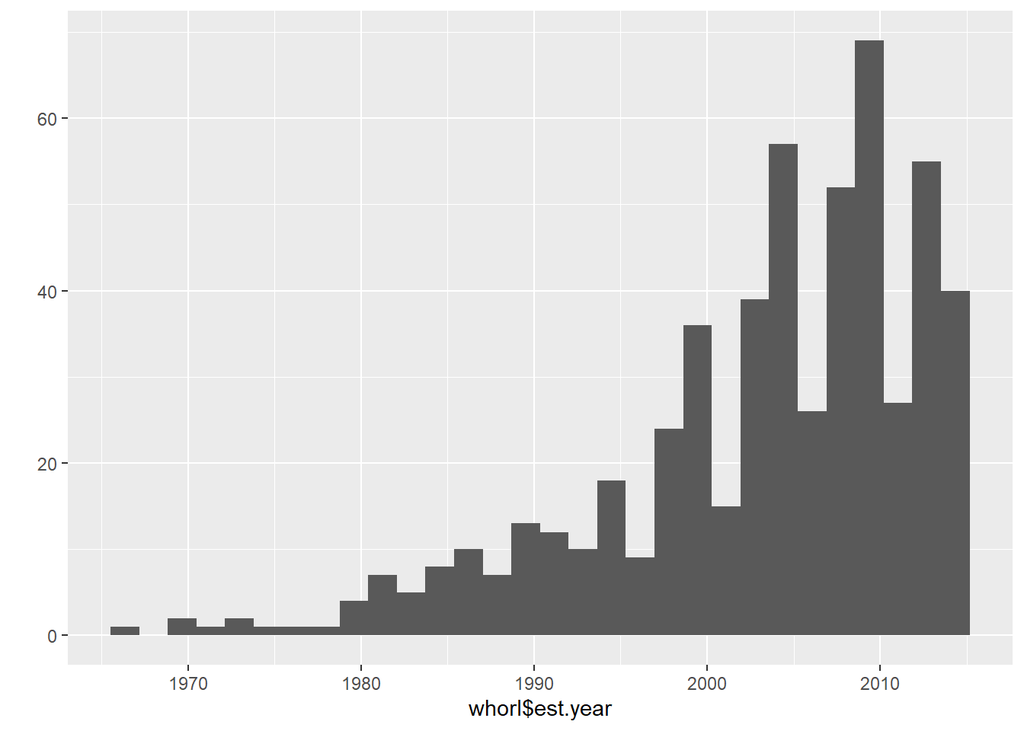

The above histogram for establishment year are left skewed.

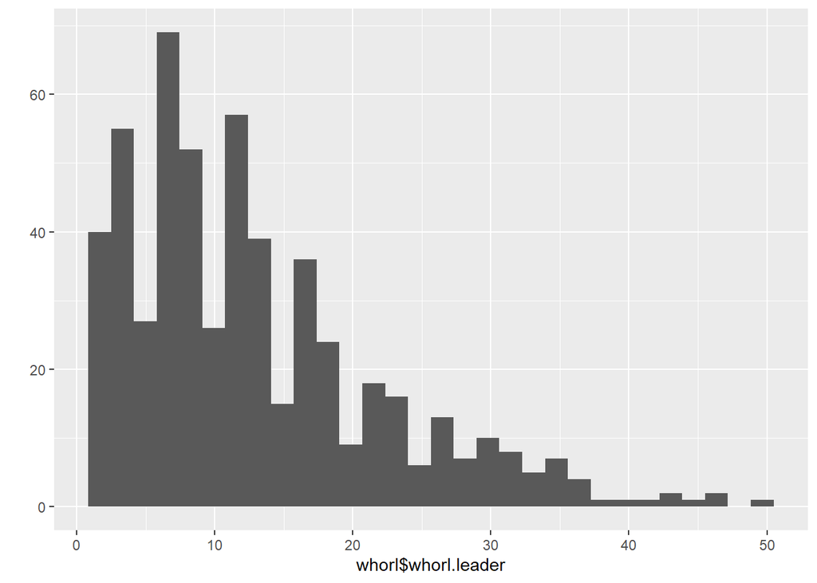

The above histogram is right skewed for saplings age. This is just the reverse of the previous histogram.

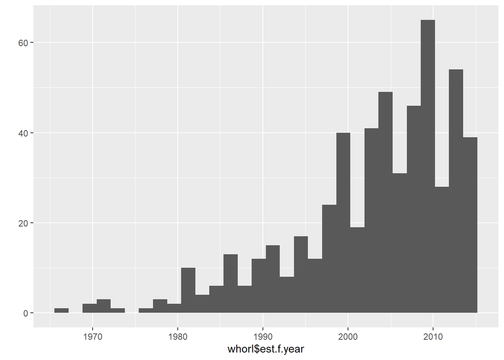

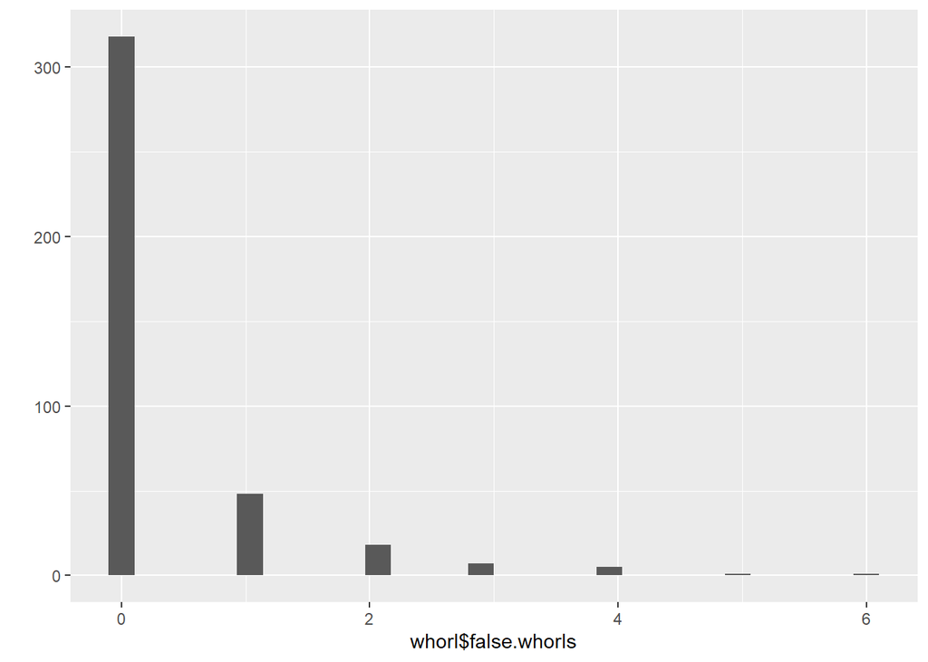

The above histogram is of false branch whorls. In some cases, PICO can put on an additional branch whorl in a growing season, referred to as a false branch whorl. It seems that large errors from false whorls are relatively small, and we had no means of confirming whether what we thought were false whorls were truly false whorls. We will acknowledge that this can happen, but we will not be taking any steps to change estimated age based on false whorls

# Organization data

Here we will organize our data into the plot level and then have sapling establishment years with counts that we can then use for analysis.

```r
whorl$plot.no = factor(whorl$plot.no)
```

## Seedling/sapling age range

```r
whorl_age = whorl %>%
  mutate(age = (2016-est.year))

median(whorl_age$age)
```

```
## [1] 11
```

```r
range(whorl_age$age)
```

```
## [1]  1 49
```

```r
median(whorl_age$DBH)
```

```
## [1] 1
```

```r
range(whorl_age$DBH)
```

```
## [1]  0.5 10.0
```

```r
sumplot = whorl_age %>%
  group_by(plot.no) %>%
  summarise(n = n())

median(sumplot$n)
```

```
## [1] 24.5
```

```r
range(sumplot$n)
```

```
## [1]  3 69
```

Reorganize the data to the plot level with the number of saplings per establishment year.

```r
plot.level = whorl %>%
  group_by(plot.no, est.year) %>%
  summarise(n = n()) %>%
  spread(est.year, n, fill = 0)

head(plot.level)
```

```
## # A tibble: 6 x 45
## # Groups:   plot.no [20]
##   plot.no `1967` `1969` `1971` `1973` `1974` `1976` `1978` `1979` `1980`
##   <fct>    <dbl>  <dbl>  <dbl>  <dbl>  <dbl>  <dbl>  <dbl>  <dbl>  <dbl>
## 1 64           0      0      0      0      0      0      0      1      0
## 2 65           0      0      0      0      0      0      0      0      0
## 3 66           0      0      0      0      0      0      0      0      0
## 4 67           0      0      0      0      0      0      0      0      0
## 5 68           0      0      0      0      0      0      0      0      0
## 6 69           1      2      1      0      0      1      0      0      1
## # ... with 35 more variables: `1981` <dbl>, `1982` <dbl>, `1983` <dbl>,
## #   `1984` <dbl>, `1985` <dbl>, `1986` <dbl>, `1987` <dbl>, `1988` <dbl>,
## #   `1989` <dbl>, `1990` <dbl>, `1991` <dbl>, `1992` <dbl>, `1993` <dbl>,
## #   `1994` <dbl>, `1995` <dbl>, `1996` <dbl>, `1997` <dbl>, `1998` <dbl>,
## #   `1999` <dbl>, `2000` <dbl>, `2001` <dbl>, `2002` <dbl>, `2003` <dbl>,
## #   `2004` <dbl>, `2005` <dbl>, `2006` <dbl>, `2007` <dbl>, `2008` <dbl>,
## #   `2009` <dbl>, `2010` <dbl>, `2011` <dbl>, `2012` <dbl>, `2013` <dbl>,
## #   `2014` <dbl>, `2015` <dbl>
```

Rename the columns.

```r
names(plot.level)[2:45] = c("y1967", "y1969", "y1971", "y1973", "y1974", "y1976", "y1978", "y1979", "y1980", "y1981", "y1982", "y1983", "y1984", "y1985", "y1986", "y1987", "y1988", "y1989", "y1990", "y1991", "y1992", "y1993", "y1994", "y1995", "y1996", "y1997", "y1998", "y1999", "y2000", "y2001", "y2002", "y2003", "y2004", "y2005", "y2006", "y2007", "y2008", "y2009", "y2010", "y2011", "y2012", "y2013", "y2014", "y2015")

head(plot.level)
```

```
## # A tibble: 6 x 45
## # Groups:   plot.no [20]
##   plot.no y1967 y1969 y1971 y1973 y1974 y1976 y1978 y1979 y1980 y1981 y1982
##   <fct>   <dbl> <dbl> <dbl> <dbl> <dbl> <dbl> <dbl> <dbl> <dbl> <dbl> <dbl>
## 1 64          0     0     0     0     0     0     0     1     0     2     0
## 2 65          0     0     0     0     0     0     0     0     0     0     0
## 3 66          0     0     0     0     0     0     0     0     0     0     0
## 4 67          0     0     0     0     0     0     0     0     0     0     1
## 5 68          0     0     0     0     0     0     0     0     0     0     0
## 6 69          1     2     1     0     0     1     0     0     1     1     3
## # ... with 33 more variables: y1983 <dbl>, y1984 <dbl>, y1985 <dbl>,
## #   y1986 <dbl>, y1987 <dbl>, y1988 <dbl>, y1989 <dbl>, y1990 <dbl>,
## #   y1991 <dbl>, y1992 <dbl>, y1993 <dbl>, y1994 <dbl>, y1995 <dbl>,
## #   y1996 <dbl>, y1997 <dbl>, y1998 <dbl>, y1999 <dbl>, y2000 <dbl>,
## #   y2001 <dbl>, y2002 <dbl>, y2003 <dbl>, y2004 <dbl>, y2005 <dbl>,
## #   y2006 <dbl>, y2007 <dbl>, y2008 <dbl>, y2009 <dbl>, y2010 <dbl>,
## #   y2011 <dbl>, y2012 <dbl>, y2013 <dbl>, y2014 <dbl>, y2015 <dbl>
```

We will also add some condensed categories for establishment as pre-outbreak (before 1999) and post-outbreak (1999-2015) with 1999 being the break point as well as pre-outbreak (before 1999), during outbreak (1999-2006) and post-outbreak (2006-2015).

# Statistical Analysis

Group and select the data needed for the analysis

- Pre 1990-1998
- During 1999-2006
- Post 2007-2015

```r
plot.level1990 = plot.level %>%
    mutate(pre1990 = y1990 + y1991 + y1992 + y1993 + y1994 + y1995 + y1996 + y1997 + y1998) %>%
    mutate(during1999 = y1999 + y2000 + y2001 + y2002 + y2003 + y2004 + y2005 + y2006) %>%
    mutate(post2007 =  y2007 + y2008 + y2009 + y2010 + y2011 + y2012 + y2013 + y2014 + y2015)

head(plot.level1990)
```

```
## # A tibble: 6 x 48
## # Groups:   plot.no [20]
##   plot.no y1967 y1969 y1971 y1973 y1974 y1976 y1978 y1979 y1980 y1981 y1982
##   <fct>   <dbl> <dbl> <dbl> <dbl> <dbl> <dbl> <dbl> <dbl> <dbl> <dbl> <dbl>
## 1 64          0     0     0     0     0     0     0     1     0     2     0
## 2 65          0     0     0     0     0     0     0     0     0     0     0
## 3 66          0     0     0     0     0     0     0     0     0     0     0
## 4 67          0     0     0     0     0     0     0     0     0     0     1
## 5 68          0     0     0     0     0     0     0     0     0     0     0
## 6 69          1     2     1     0     0     1     0     0     1     1     3
## # ... with 36 more variables: y1983 <dbl>, y1984 <dbl>, y1985 <dbl>,
## #   y1986 <dbl>, y1987 <dbl>, y1988 <dbl>, y1989 <dbl>, y1990 <dbl>,
## #   y1991 <dbl>, y1992 <dbl>, y1993 <dbl>, y1994 <dbl>, y1995 <dbl>,
## #   y1996 <dbl>, y1997 <dbl>, y1998 <dbl>, y1999 <dbl>, y2000 <dbl>,
## #   y2001 <dbl>, y2002 <dbl>, y2003 <dbl>, y2004 <dbl>, y2005 <dbl>,
## #   y2006 <dbl>, y2007 <dbl>, y2008 <dbl>, y2009 <dbl>, y2010 <dbl>,
## #   y2011 <dbl>, y2012 <dbl>, y2013 <dbl>, y2014 <dbl>, y2015 <dbl>,
## #   pre1990 <dbl>, during1999 <dbl>, post2007 <dbl>
```

```r
dis1990 = plot.level1990 %>%
    dplyr::select(plot.no, pre1990:post2007) %>%
    tidyr::gather(est.time, sapling.ct, pre1990:post2007) %>%
    mutate(transunique = paste(plot.no, est.time, sep = ".") )

head(dis1990)
```

```
## # A tibble: 6 x 4
## # Groups:   plot.no [20]
##   plot.no est.time sapling.ct transunique
##   <fct>   <chr>         <dbl> <chr>
## 1 64      pre1990           0 64.pre1990
## 2 65      pre1990           5 65.pre1990
## 3 66      pre1990           6 66.pre1990
## 4 67      pre1990           2 67.pre1990
## 5 68      pre1990          13 68.pre1990
## 6 69      pre1990           3 69.pre1990
```

```r
dis1990$est.time = factor(dis1990$est.time, levels = c("pre1990", "during1999", "post2007"),
       labels = c("Pre (1990-1998)", "During (1999-2006)", "Post (2007-2015)"))
head(dis1990)
```

```
## # A tibble: 6 x 4
## # Groups:   plot.no [20]
##   plot.no est.time        sapling.ct transunique
##   <fct>   <fct>                <dbl> <chr>
## 1 64      Pre (1990-1998)          0 64.pre1990
## 2 65      Pre (1990-1998)          5 65.pre1990
## 3 66      Pre (1990-1998)          6 66.pre1990
## 4 67      Pre (1990-1998)          2 67.pre1990
## 5 68      Pre (1990-1998)         13 68.pre1990
## 6 69      Pre (1990-1998)          3 69.pre1990
```

## Statistical model with negative binomial

```r
fitdis1990nb = glm.nb(sapling.ct ~ est.time, data = dis1990)
```

### Residuals

In the plot below we are looking for the points in the QQ plot to fall along the RED linen. In the Residuals vs.predicted plot were are looking for the lines to be relatively horizontal. All looks good.

```
## plotSimulatedResiduals is deprecated, switch your code to using the plot function
```

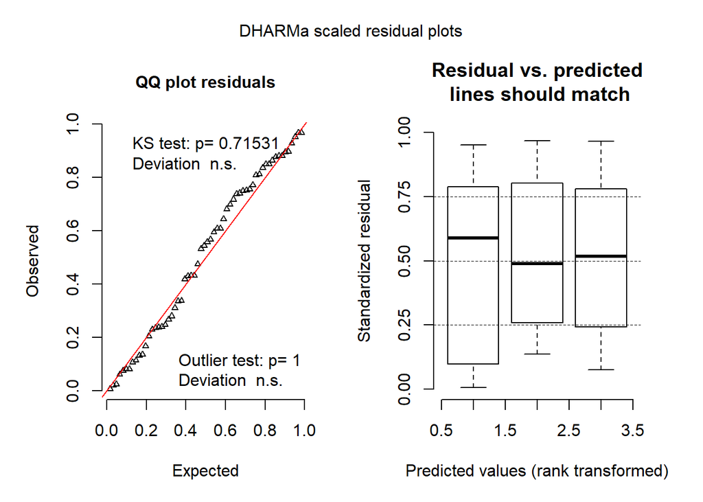

```r
plotSimulatedResiduals(simulationOutput = fitdis1990nb.res)
```

QQ plot looks ok with no significant deviations from the plot line. The residual vs predicted plot looks ok, lines are relatively horizontal. Th lack of horizontality maybe due to lack of data in certain regions, but these generally look adequate.

QQplot looks ok with no significant deviations. The residual vs predicted plot looks ok with lines that are relatively horizontal.

### Overdispersion

```r
simulationOutput1990nb <- simulateResiduals(fittedModel = fitdis1990nb, refit = T, n = 20)
testOverdispersion(simulationOutput1990nb)
```

```
## testOverdispersion is deprecated, switch your code to using the testDispersion function
```

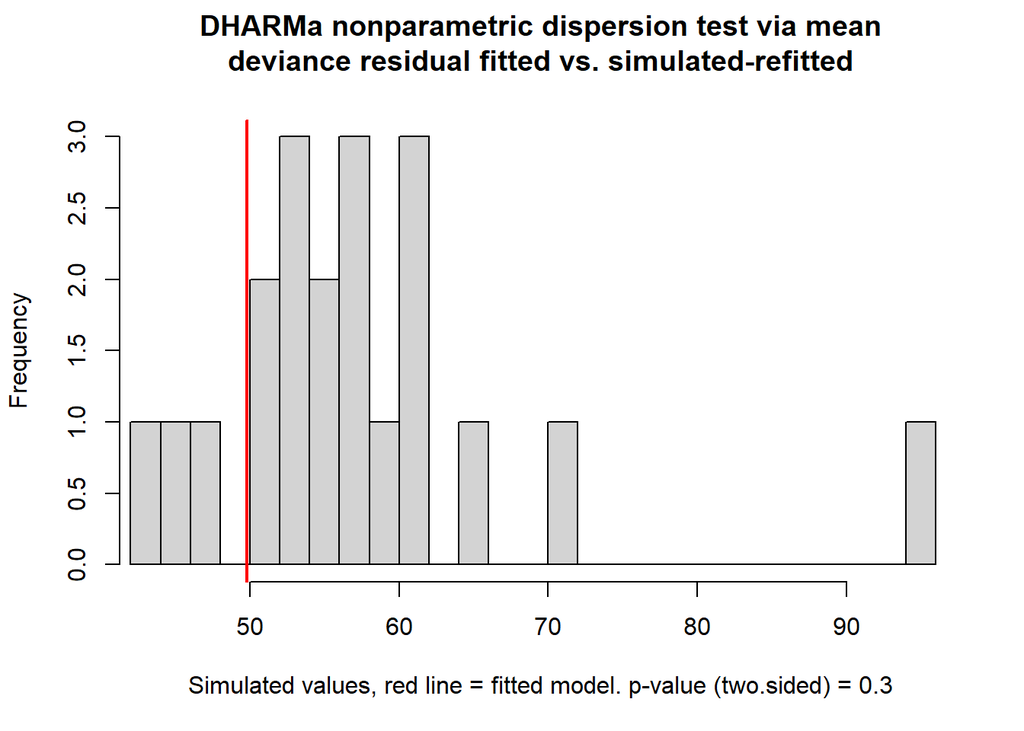

```
##
##  DHARMa nonparametric dispersion test via mean deviance residual
##  fitted vs. simulated-refitted
##
## data:  simulationOutput
## dispersion = 0.86278, p-value = 0.3
## alternative hypothesis: two.sided
```

### Summary

```r
summary(fitdis1990nb)
```

```
##
## Call:
## glm.nb(formula = sapling.ct ~ est.time, data = dis1990, init.theta = 0.7905699946,
##     link = log)
##
## Deviance Residuals:
##     Min       1Q   Median       3Q      Max
## -2.1023  -1.2800  -0.3134   0.3698   1.8028
##
## Coefficients:
##                            Estimate Std. Error z value Pr(>|z|)
## (Intercept)                  1.3737     0.2755   4.986 6.16e-07 ***
## est.timeDuring (1999-2006)   0.7838     0.3807   2.059  0.03950 *
## est.timePost (2007-2015)     1.1236     0.3785   2.969  0.00299 **
## ---
## Signif. codes:  0 '***' 0.001 '**' 0.01 '*' 0.05 '.' 0.1 ' ' 1
##
## (Dispersion parameter for Negative Binomial(0.7906) family taken to be 1)
##
##     Null deviance: 77.730  on 59  degrees of freedom
## Residual deviance: 69.154  on 57  degrees of freedom
## AIC: 376.42
##
## Number of Fisher Scoring iterations: 1
##
##
##               Theta:  0.791
##           Std. Err.:  0.168
##
##  2 x log-likelihood:  -368.416
```

### Estimates

```r
lsmeans(fitdis1990nb, pairwise ~ est.time, type = "response", infer = TRUE, level = .95, adjust = 'bon')
```

```
## $lsmeans
##  est.time           response   SE  df asymp.LCL asymp.UCL
##  Pre (1990-1998)        3.95 1.09 Inf      2.30      6.78
##  During (1999-2006)     8.65 2.27 Inf      5.17     14.48
##  Post (2007-2015)      12.15 3.15 Inf      7.31     20.21
##
## Confidence level used: 0.95
## Intervals are back-transformed from the log scale
##
## $contrasts
##  contrast                              ratio    SE  df z.ratio p.value
##  Pre (1990-1998) / During (1999-2006)  0.457 0.174 Inf -2.059  0.1185
##  Pre (1990-1998) / Post (2007-2015)    0.325 0.123 Inf -2.969  0.0090
##  During (1999-2006) / Post (2007-2015) 0.712 0.263 Inf -0.920  1.0000
##
## P value adjustment: bonferroni method for 3 tests
## Tests are performed on the log scale
```

```r
summary(lsmeans(fitdis1990nb, pairwise ~ est.time), type = "response", infer = TRUE, level = .95, adjust = "bon")
```

```
## $lsmeans
##  est.time           response   SE  df asymp.LCL asymp.UCL z.ratio p.value
##  Pre (1990-1998)        3.95 1.09 Inf      2.04      7.64 4.986   <.0001
##  During (1999-2006)     8.65 2.27 Inf      4.61     16.22 8.212   <.0001
##  Post (2007-2015)      12.15 3.15 Inf      6.53     22.62 9.622   <.0001
##
## Confidence level used: 0.95
## Conf-level adjustment: bonferroni method for 3 estimates
## Intervals are back-transformed from the log scale
## P value adjustment: bonferroni method for 3 tests
## Tests are performed on the log scale
##
## $contrasts
##  contrast                              ratio    SE  df asymp.LCL asymp.UCL
##  Pre (1990-1998) / During (1999-2006)  0.457 0.174 Inf     0.184     1.136
##  Pre (1990-1998) / Post (2007-2015)    0.325 0.123 Inf     0.131     0.805
##  During (1999-2006) / Post (2007-2015) 0.712 0.263 Inf     0.294     1.723
##  z.ratio p.value
##  -2.059  0.1185
##  -2.969  0.0090
##  -0.920  1.0000
##
## Confidence level used: 0.95
## Conf-level adjustment: bonferroni method for 3 estimates
## Intervals are back-transformed from the log scale
## P value adjustment: bonferroni method for 3 tests
## Tests are performed on the log scale
```

```r
summary(lsmeans(fitdis1990nb, revpairwise ~ est.time), type = "response", infer = TRUE, level = .95, adjust = "bon")
```

```
## $lsmeans
##  est.time           response   SE  df asymp.LCL asymp.UCL z.ratio p.value
##  Pre (1990-1998)        3.95 1.09 Inf      2.04      7.64 4.986   <.0001
##  During (1999-2006)     8.65 2.27 Inf      4.61     16.22 8.212   <.0001
##  Post (2007-2015)      12.15 3.15 Inf      6.53     22.62 9.622   <.0001
##
## Confidence level used: 0.95
## Conf-level adjustment: bonferroni method for 3 estimates
## Intervals are back-transformed from the log scale
## P value adjustment: bonferroni method for 3 tests
## Tests are performed on the log scale
##
## $contrasts
##  contrast                              ratio    SE  df asymp.LCL asymp.UCL
##  During (1999-2006) / Pre (1990-1998)   2.19 0.834 Inf      0.88      5.45
##  Post (2007-2015) / Pre (1990-1998)     3.08 1.164 Inf      1.24      7.61
##  Post (2007-2015) / During (1999-2006)  1.40 0.519 Inf      0.58      3.40
##  z.ratio p.value
##  2.059   0.1185
##  2.969   0.0090
##  0.920   1.0000
##
## Confidence level used: 0.95
## Conf-level adjustment: bonferroni method for 3 estimates
## Intervals are back-transformed from the log scale
## P value adjustment: bonferroni method for 3 tests
## Tests are performed on the log scale
```

#### Data Frame

```r
( fitdis1990nb.graph = data.frame(summary(lsmeans(fitdis1990nb, pairwise ~ est.time, type = "response", infer = TRUE))) )
```

```
##     lsmeans.est.time lsmeans.response lsmeans.SE lsmeans.df
## 1    Pre (1990-1998)             3.95   1.088250        Inf
## 2 During (1999-2006)             8.65   2.272595        Inf
## 3   Post (2007-2015)            12.15   3.153404        Inf
##   lsmeans.asymp.LCL lsmeans.asymp.UCL
## 1          2.301896          6.778108
## 2          5.168706         14.476059
## 3          7.305600         20.206759
##                      contrasts.contrast contrasts.ratio contrasts.SE
## 1  Pre (1990-1998) / During (1999-2006)       0.4566474    0.1738439
## 2    Pre (1990-1998) / Post (2007-2015)       0.3251029    0.1230524
## 3 During (1999-2006) / Post (2007-2015)       0.7119342    0.2629212
##   contrasts.df contrasts.z.ratio contrasts.p.value
## 1          Inf        -2.0589745       0.098521362
## 2          Inf        -2.9685730       0.008409834
## 3          Inf        -0.9200237       0.627605923
```

```r
( response.graph = data.frame(summary(lsmeans(fitdis1990nb, pairwise ~ est.time), type = "response", infer = TRUE)$lsmeans))
```

```
##             est.time response       SE  df asymp.LCL asymp.UCL  z.ratio
## 1    Pre (1990-1998)     3.95 1.088250 Inf  2.301896  6.778108 4.986149
## 2 During (1999-2006)     8.65 2.272595 Inf  5.168706 14.476059 8.212150
## 3   Post (2007-2015)    12.15 3.153404 Inf  7.305600 20.206759 9.622156
##        p.value
## 1 6.159465e-07
## 2 2.172634e-16
## 3 6.446563e-22
```

## Figures

Set theme

```r
my_theme = theme_bw() +
    theme(axis.ticks.y = element_blank(),
        axis.text.y = element_blank()) +
    theme(legend.position = "none") +
    theme(plot.margin = unit(c(t = 0.1, r = 0.1, b = 0.1, l = 0.5), "cm")) +
    theme(panel.grid.major = element_blank() )
```

### Manuscript Figure: Response Estimates

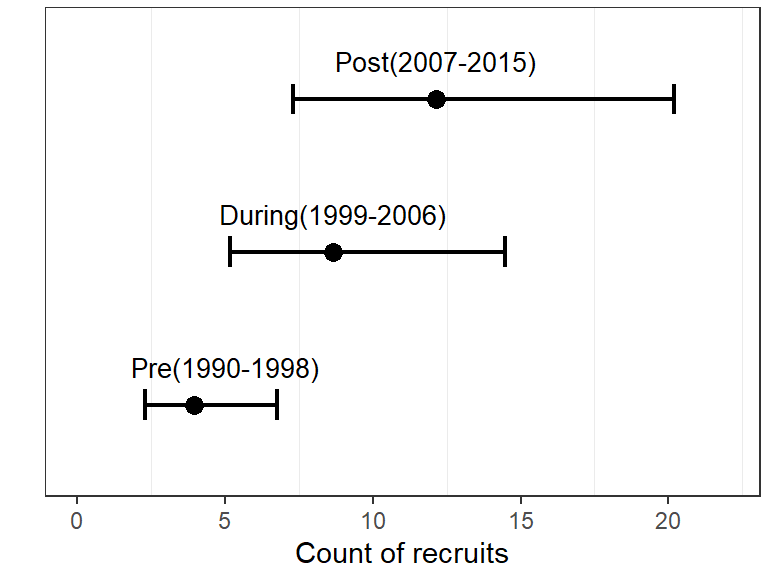

Save the manuscript figure

Extract contrast for graph

```r
( rec.contrast = data.frame(summary(lsmeans(fitdis1990nb, revpairwise ~ est.time),type = "response", infer = TRUE)$contrasts))
```

```
##                                contrast    ratio        SE  df asymp.LCL
## 1  During (1999-2006) / Pre (1990-1998) 2.189873 0.8336765 Inf 0.8972739
## 2    Post (2007-2015) / Pre (1990-1998) 3.075949 1.1642558 Inf 1.2668279
## 3 Post (2007-2015) / During (1999-2006) 1.404624 0.5187355 Inf 0.5910990
##   asymp.UCL   z.ratio     p.value
## 1  5.344573 2.0589745 0.098521362
## 2  7.468627 2.9685730 0.008409834
## 3  3.337799 0.9200237 0.627605923
```

### Supplement Figure: Odds Ratio

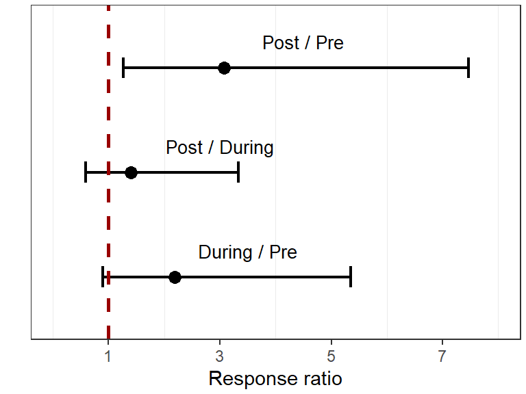

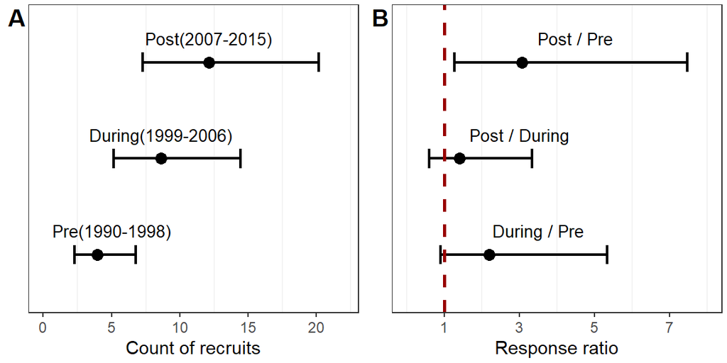

```r
(grid1 = cowplot::plot_grid(fig1, fig2, labels = c("A", "B"), ncol = 2))
```